# Complexity, Recursion, Sorting and Searching

##### *Will you use recursion for your research in political science? Probably not.*

If you are going to into industry, these become really important for coding (technical) interviews.

More resources on that:

- https://leetcode.com/
- https://open.kattis.com/problems

### 1. Recursion

- Recursion refers to when a function **calls itself** as part of its definition.

To implement it you will need to know the following for your context:

- The base case
- When to call the function
- When to stop calling it

##### The typical example is the factorial function $(\cdot)!$

$$\begin{align} ( n)! &= n \times (n-1)! \\ &= n \times (n-1) \times (n-2)! \\ &= n * (n-1) \times (n-2) ... \times 2 \times 1\end{align}$$

##### An example from the physical world

- When two parallel mirrors face each other, any object in between them would be reflected recursively.

##### When should you use it?

##### Pros

- Make the code look clean
- Sequence generation is easier

##### Cons

- Logic behind is hard to follow sometimes
- Recursiveness is expensive and inefficient uses a lot of memory
- Hard to debug

Source: https://www.programiz.com/python-programming/recursion

- Remember the basic structure of recursion

```python
# def some_function(n):
#   if base case:
#       return something
#   else:
#       return some_function(a recursive call)
```

#### 1.1 Recursive Factorial Function

##### Let's implement $n! = n \times (n-1) \times (n - 2) \times ... \times 2 \times 1$ recursivly in Python

```python
def nFactorial(n):
    if n == 1:
        return n
    else:
        return n * nFactorial(n-1)

nFactorial(5)
```

```
120
```

##### What is happening in the background?

1. $n = 5$, so `return` $5 \times f(4)$
2. $n = 4$, so `return` $5 \times 4 \times f(3)...$
3. $\dots$
4. $n = 1$, so `return` $n = 5 \times 4 \times 3 \times 2 \times f(1) = 120$
- Check result using `math`

```python
import math

math.factorial(5)
```

```
120
```

#### 1.2 Recursive Fibonacci Function

##### Let's implement $x_{i} = x_{i-1} + x_{i-2}$, where $x_1 = 1, x_2 = 1$

- We'll find the $n^{th}$ number in the sequence $\{1, 1, 2, 3, 5, 8, 13, 21...\}$

```python
def fib(n):
    if n <= 1:
        return 1
    return fib(n-1) + fib(n-2)
```

```python
fib(10)
```

```
89
```

##### What is happening in the background?

- At `fib(0)`: 0 <= 1, so `return` $n = 1$
- At `fib(1)`: 1 <= 1, so `return` $n = 1$
- At `fib(2)`: 2 > 1, so `return fib(1) + fib(0)` = $1 + 1 = 2$
- At `fib(3)`: 3 > 1, so `return fib(2) + fib(1)` = $2 + 1 = 3$
- We can also use our implementation to print the first $n$ terms

```python
for i in range(11):
    print("{0} : {1}".format(i, fib(i)))
```

```
0 : 1
1 : 1
2 : 2
3 : 3
4 : 5
5 : 8
6 : 13
7 : 21
8 : 34
9 : 55
10 : 89
```

### 2. Search Algorithms

- **The goal**: Find the position of a value within a list.
- There are many searching techniques. Here we'll cover two:
  - Linear search
  - Binary search

Source: https://python-textbok.readthedocs.io/en/1.0/Sorting_and_Searching_Algorithms.html

#### 2.1 Linear Search

1. Check the values in sequence until the desired value is found
2. Return desired element in a list along with its position

```python
import random

# list of integers 0-26
mylist = list(range(26))

# shuffle them
random.shuffle(mylist)
print(mylist)
```

```
[13, 8, 4, 10, 11, 17, 3, 24, 23, 16, 19, 5, 9, 25, 18, 6, 21, 0, 1, 2, 15, 22, 14, 7, 12, 20]
```

##### Implementation

```python
def linear_search(mylist, element):
    # initialize steps counter
    steps = 0
    for item in mylist:
        # index will start at 1
        steps += 1
        # stop when we find our 'element'
        if item == element:
            print("Steps:" + str(steps))
            return item
```

- How many steps to find each of these?

```python
linear_search(mylist, 1)
```

```
Steps:19
```

```
1
```

```python
linear_search(mylist, 5)
```

```
Steps:12
```

```
5
```

```python
linear_search(mylist, 10)
```

```
Steps:4
```

```
10
```

#### 2.2 Binary Search:

- Requires a pre-sorted list
1. Check for the desired value starting in the middle of the list
2. Repeatedly discard the half of the list that definitely does not contain the element we are searching for

```python
def binary_search(sorted_list, element):
    # print list elements and size
    print("Input list is {0}".format(sorted_list))
    print("Input size is {0}".format(len(sorted_list)))

    # find the middle (root) of list
    middle = len(sorted_list)//2
    # store middle value
    median = sorted_list[middle]

    # what is this taking care of?
    if len(sorted_list) <= 1:
        if element == median:
            return median
        else:
            return 'No such element'

    # leveraging sorted data
    if element < median:
        left = sorted_list[0:middle]
        # RECURSIVE CALL!
        return binary_search(sorted_list = left, element = element)
    else:
        # RECURSIVE CALL!
        right = sorted_list[middle:]
        return binary_search(sorted_list = right, element = element)
```

- List all even numbers between 0 and 1000

```python
mylist = range(0, 1000, 2)
```

```python
binary_search(mylist, 72)
```

```
Input list is range(0, 1000, 2)
Input size is 500
Input list is range(0, 500, 2)
Input size is 250
Input list is range(0, 250, 2)
Input size is 125
Input list is range(0, 124, 2)
Input size is 62
Input list is range(62, 124, 2)
Input size is 31
Input list is range(62, 92, 2)
Input size is 15
Input list is range(62, 76, 2)
Input size is 7
Input list is range(68, 76, 2)
Input size is 4
Input list is range(72, 76, 2)
Input size is 2
Input list is range(72, 74, 2)
Input size is 1
```

```
72
```

```python
binary_search(mylist, 71)
```

```
Input list is range(0, 1000, 2)
Input size is 500
Input list is range(0, 500, 2)
Input size is 250
Input list is range(0, 250, 2)
Input size is 125
Input list is range(0, 124, 2)
Input size is 62
Input list is range(62, 124, 2)
Input size is 31
Input list is range(62, 92, 2)
Input size is 15
Input list is range(62, 76, 2)
Input size is 7
Input list is range(68, 76, 2)
Input size is 4
Input list is range(68, 72, 2)
Input size is 2
Input list is range(70, 72, 2)
Input size is 1
```

```
'No such element'
```

### 3. Sorting Algorithms

- **The goal**: Order the values in a list.
- Again, there are many other sorting algorithms but here we'll cover two:
  - Selection sort
  - Bogo sort

Source: https://python-textbok.readthedocs.io/en/1.0/Sorting_and_Searching_Algorithms.html

#### 3.1 Selection Sort: repeated selection of the smallest item

1. Find the minimum in the unsorted list
2. Remove the minimum and store as the first element of a new list
3. Repeat until unsorted list is empty

```python
my_numbers = [1, 9, 8, 5, 4, 6, 0, 2, 3, 7]
```

```python
def selection_sort(numbers):
    # preserves original input
    numbers = numbers.copy()
    # sorted list
    answer = []
    # while unsorted list empty...
    while len(numbers) > 0:
        # add minimum to ordered list
        answer.append(min(numbers))
        # delete from unsorted list
        del numbers[numbers.index(answer[-1])]
    return answer
```

```python
selection_sort(numbers = my_numbers)
```

```
[0, 1, 2, 3, 4, 5, 6, 7, 8, 9]
```

#### 3.2 Bogo Sort

- Randomize the order of all elements in a list
  1. If sorted: Great!
  2. If not sorted: randomize again
- Very silly, very inefficient, just created for fun

```python
my_numbers2 = [8, 2, 1, 3, 4]
```

```python
def bogo_sort(numbers):
    # initialize counter
    n = 0
    # copy of list
    answer = numbers.copy()
    # while the copy isn't sorted...
    while answer != sorted(numbers):
        # keep shuffling
        random.shuffle(answer)
        # add to counter
        n += 1
    steps = n
    return answer, steps
```

```python
bogo_sort(my_numbers2)
```

```
([1, 2, 3, 4, 8], 33)
```

### 4. Time Complexity

- Refers to how the number of steps required for an algorithm to complete depends on the size of the input
- Also to the amount of time/the number of operations need to complete a task.
- Commonly express this number as $n$

##### $O(n)$ notation:

- Big-O notation is a relative representation of the complexity of an algorithm.
- Classify algorithms according to how their running time or space requirements grow as the input size
- Informally, we can think of the Big-O notation as the run time in the worst case scenario
- See Towards Data Science for more information on the Big O notation: https://bit.ly/3iYs4kb
- Another good resource: https://www.freecodecamp.org/news/big-o-notation-why-it-matters-and-why-it-doesnt-1674cfa8a23c/

| Name | Time Complexity |
| --- | --- |
| Constant Time | $O(1)$ |
| Logarithmic Time | $O(\log n)$ |
| Linear Time | $O(n)$ |
| Quasilinear Time | $O(n \log n)$ |
| Quadratic Time | $O(n^2)$ |
| Exponential Time | $O(2^n)$ |
| Factorial Time | $O(n!)$ |

##### Let's assess the complexity of some algorithms

- Short list

```python
s = [i for i in range(10)]
```

- Long list

```python
l = [i for i in range(1000)]
```

#### 4.1 Constant Time $O(1)$

- Time to complete is independent of the size of `x`.

```python
def o_1(x):
    out = x[5]
    return out
```

##### Few data

```python
o_1(s)
```

```
5
```

##### Many data

```python
o_1(l)
```

```
5
```

#### 4.2 Linear Time $O(n)$

```python
def o_n(x):
    for i in range(len(x)):
        x[i] += 1
        return x
```

##### Few data

```python
o_n(s)
```

```
[1, 1, 2, 3, 4, 5, 6, 7, 8, 9]
```

##### Many data

```python
# o_n(l)
```

#### 4.3 Quadratic Time $O(n^2)$

- Time to complete increases at a rate of $x^2$ for each additional item we add to `x` since we loop twice.

```python
def o_nsqr(x):
    out = []
    for i in range(len(x)):
        for j in range(len(x)):
          out.append(i + j)
    return out
```

##### Few data

```python
# o_nsqr(s)
```

##### Many data

```python
# o_nsqr(l)
```

#### 4.4 Exponential Time $O(2^n)$

- For every increase in x, we are creating many (exponentially) more recurisons

```python
def fib(x):
  if x <= 1:
      return x
  return fib(x - 1) + fib(x - 2)
```

```python
fib(10)
```

[output not shown]

```python
fib(35)
```

[output not shown]

### 5. Simple Plotting in Python

##### Let's practice graphically representing time complexity

- You can use `matplotlib` to create plots
- And `seaborn` to make your plots prettier

```python
# !pip3 install matplotlib
```

```python
# ! pip3 install seaborn
```

```python
import matplotlib.pyplot as plt
import math
import numpy as np
```

```
Matplotlib is building the font cache; this may take a moment.
```

##### Define some representative sequences to plot

```python
n = list(range(1, 11))
O1 = [1 for i in n]
OLogN = [math.log(i) for i in n]
OnLogN = [i * math.log(i) for i in n]
On2 = [i * 2 for i in n]
O2n = [2 ** i for i in n]
OnF = [math.factorial(i) for i in n]
```

##### Plot them against each other

[figure not shown]

```python
plt.plot(n, O1, 'r-', label = "O(1)")
plt.plot(n, OLogN, 'b-', label = "O(Log n)")
plt.plot(n, OnLogN, 'g-', label = "O(n Log n )")
plt.plot(n, On2, 'y-', label = "O(2n)")
plt.plot(n, O2n, 'm-', label = "O(n^2)")
plt.plot(n, OnF, 'k-', label = "O(n!)")
plt.xlim(1, 10)
plt.ylim(1, 100)
plt.xlabel('N')
plt.ylabel('Big O')
plt.legend()
plt.show()
```

##### X-axis: no. of elements in list

```python
x1 = range(1, 101)
x2 = range(1, 101)
```

##### Y-axis: time

```python
y1 = range(1, 101)
y2 = [i * 0.5 for i in range(1, 101)]
```

- Adjust the area around the plot

```python
plt.subplots_adjust(left = .13, right = .95, top = .9, bottom = .3)
```

- Plot the data

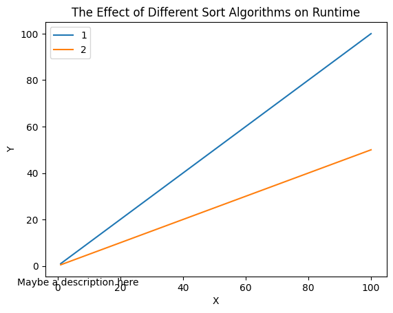

```python
plt.plot(x1, y1)
plt.plot(x2, y2)

# legend
plt.legend(['1', '2'], loc = "upper left", prop = {"size":10})
# y label
plt.ylabel("Y")
# x label
plt.xlabel("X")
# plot title
plt.title("The Effect of Different Sort Algorithms on Runtime")
# plot description
txt = """
Maybe a description here
"""
plt.figtext(.2, .05, txt, fontsize = 10, ha = "center")
plt.show()
# Save plot
plt.savefig('/Users/almavelazquez/Documents/GitHub/PythonCamp2024/Day10/Lecture/plot.pdf')
```

```python
# Copyright of the original version:

# Copyright (c) 2014 Matt Dickenson
#
# Permission is hereby granted, free of charge, to any person obtaining a copy
# of this software and associated documentation files (the "Software"), to deal
# in the Software without restriction, including without limitation the rights
# to use, copy, modify, merge, publish, distribute, sublicense, and/or sell
# copies of the Software, and to permit persons to whom the Software is
# furnished to do so, subject to the following conditions:
#
# The above copyright notice and this permission notice shall be included in all
# copies or substantial portions of the Software.
#
# THE SOFTWARE IS PROVIDED "AS IS", WITHOUT WARRANTY OF ANY KIND, EXPRESS OR
# IMPLIED, INCLUDING BUT NOT LIMITED TO THE WARRANTIES OF MERCHANTABILITY,
# FITNESS FOR A PARTICULAR PURPOSE AND NONINFRINGEMENT. IN NO EVENT SHALL THE
# AUTHORS OR COPYRIGHT HOLDERS BE LIABLE FOR ANY CLAIM, DAMAGES OR OTHER
# LIABILITY, WHETHER IN AN ACTION OF CONTRACT, TORT OR OTHERWISE, ARISING FROM,
# OUT OF OR IN CONNECTION WITH THE SOFTWARE OR THE USE OR OTHER DEALINGS IN THE
# SOFTWARE.
```